# R Notebook

```r
source('~/Documents/DAC_Project/R/config.R')
```

```r
df = readFromParquet(getFilePath("train_data",".parquet"))
```

```
    EDA
```

# Distribution of target label

Plotting all variables against the target variable, we can see there is a smooth gradient of corolations, with bounds within [0.6, -0.6].

```r
# DONT RUN, TAKES A WHILE
cors = data.frame(x = colnames(df %>% removeNonNumerics %>% select(-c(customer_ID,target))), y = 'target')
cors$variableCategories = substr(cors$x, start = 1, stop = 1)
for(i in 1:nrow(cors)){
  cors[i,'cor'] = cor(df[,cors[i,1]], df[,cors[i,2]], method = "pearson", use = 'pairwise.complete.obs')
}
```

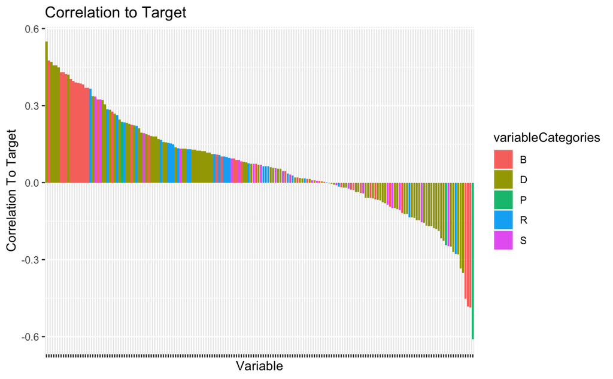

```r
cors = readRDS(getFilePath("corolationToTarget",""))

ggplot(cors, aes(x = reorder(x, -cor), y = cor, fill = variableCategories)) + geom_col(position = "identity") +
    theme(axis.text.x=element_blank()) +
    xlab("Variable") +
    ylab("Correlation To Target") +
    ggtitle("Correlation to Target")

ggsave('/Users/root1/Documents/amex-default-prediction/plots/corolationToTarget.png')
```

```r
ggplot(df,aes(x=P_2))+geom_histogram(color="skyblue")+facet_grid(~target) +
    ggtitle("Distribution of P_2 by Target")
```

```
Warning: Removed 45985 rows containing non-finite values (stat_bin).
```

```
Warning: Removed 45985 rows containing non-finite values (stat_bin).
```

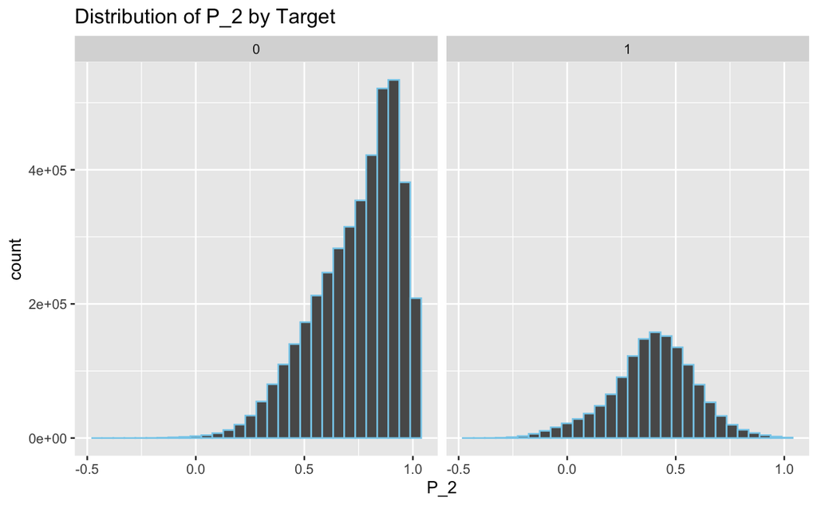

```r
ggsave('/Users/root1/Documents/amex-default-prediction/plots/P2.png')
```

```
        FEATURE ENGINEERING
```

# Missing Data

From the below barplot, we can see there are a number of variables with large amounts of missing data.  
As the models selected either suffer or are inoperable with missing data, a threshold of 0.1 was selected as cuttoff for acceptable percentage of missing values in a given column.  
Of variables beyond that threshold, 77% had over half of its data missing.

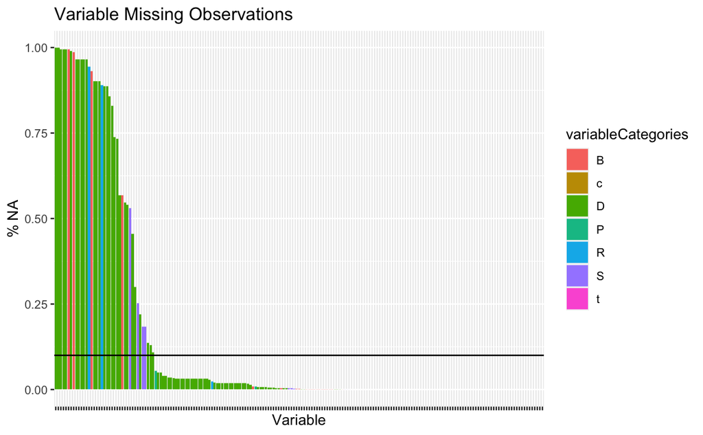

```r
naCounts = as.data.frame(getNACounts("train_data")/train_data_N)
naCounts$variableCategories = substr(rownames(naCounts), start = 1, stop = 1)
colnames(naCounts) = c('coln','variableCategories')

ggplot(naCounts, aes(x = reorder(rownames(naCounts), -coln), y = coln, fill = variableCategories)) + geom_col(position = "identity") +
    theme(axis.text.x=element_blank()) +
    xlab("Variable") +
    ylab("% NA") +
    geom_hline(yintercept =0.1) +
    ggtitle("Variable Missing Observations")

ggsave('/Users/root1/Documents/amex-default-prediction/plots/naHist.png')
```

# Low variance

Variables of low variance have a small spread, thus having the majority of the observations clustered around the mean.  
When creating data models such variables are uninformative and should be removed.  
Deciding a conservative threshold of 0.001, variables where 99.9% of the values are similar are removed.

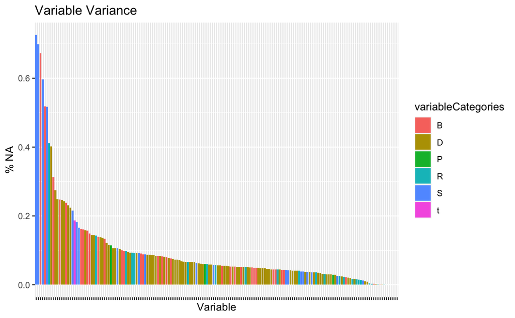

```r
vars = getVariance("train_data")
vars = data.frame(variable = colnames(vars), vars = unlist(vars))
vars$variableCategories = substr(rownames(vars), start = 1, stop = 1)

# Remove high outliers
vars = vars[vars$vars < 1,]

ggplot(vars, aes(x = reorder(variable, -vars), y = vars, fill = variableCategories)) + geom_col(position = "identity") +
    theme(axis.text.x=element_blank()) +
    xlab("Variable") +
    ylab("% NA") +
    ggtitle("Variable Variance")

ggsave('/Users/root1/Documents/amex-default-prediction/plots/variance.png')
```

# High Correlation

The correlation between each pair of variables is calculated as to determine if there are redundant highly correlated variables in the data. Allowing for a threshold of 0.9 which would indicated highly correlated variables.  
One of each variable pair above this threshold are removed as both would impart similar information to models applied.  
Aditionally, multicollinearity issues in regression models are reduced by taking this action.

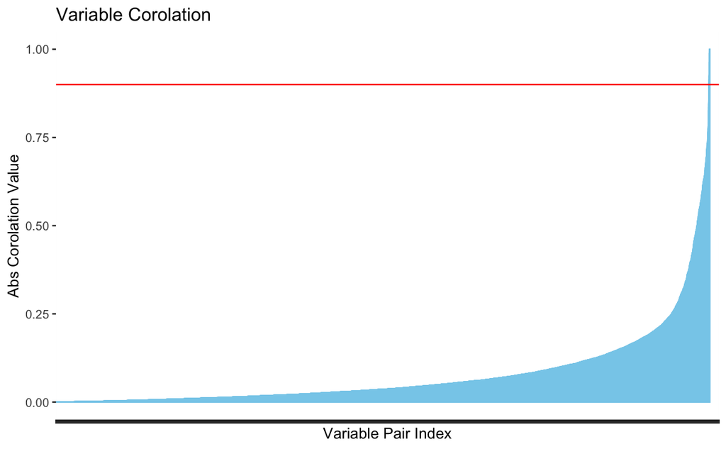

```r
x = colMeans(getCorolations("train_data"))
labs = str_split(names(x), "-")

crossCor = data.frame(
  v1 = sapply(labs, "[[", 1),
  v2 = sapply(labs, "[[", 2),
  val = x
)

crossCor$idu <- 1:nrow(crossCor)
ggplot(crossCor, aes(x=reorder(idu, abs(val)), y=abs(val))) +
    geom_col(color="skyblue") +
    theme(axis.text.x=element_blank()) +
    xlab("Variable Pair Index") +
    ylab("Abs Corolation Value") +
    geom_hline(yintercept = 0.9, col = 'red') +
    ggtitle("Variable Corolation")

ggsave('/Users/root1/Documents/amex-default-prediction/plots/correlation.png')
```

# Noise Removal

```r
noiseCols = c('S_6', 'D_111', 'B_16')
jpeg(file='/Users/root1/Documents/amex-default-prediction/plots/noise.png')
par(mfrow = c(3,1))
for(i in 1:length(noiseCols)){
  hist(df[,noiseCols[i]][[1]],  main =  noiseCols[i], xlab = "", breaks = 100000, col = 'skyblue')
}
dev.off()
```

REFERENCE : https://www.jstatsoft.org/article/view/v095i10

Kolmogorov–Smirnov test

To identify these intervals where noise occurs a one sided Kolmogorov–Smirnov goodness of fit test is implemented. The Kolmogorov–Smirnov test is a nonparametric test which measures agreement between the cumulative distribution function of observed data to a specified distribution. In this case, we are comparing to a $Uniform[0,0.01]$ distribution for each test.

The hypothesis being tested is: $H_0 : $ The sample comes from the specified theoretical distribution $H_A : $ The sample does not comes from the specified theoretical distribution

The test statistic is the absolute value of the largest distance between the two distributions functions.
$$D
= sup_x |F_n(X)−F(X)|$$

where

$n$ The sample size $F_o(X)$ The observed cumulative frequency distribution of a random sample of n observations. $F(X)$ The theoretical cumulative distribution function

This test statistic is evaluated against the K-S tables to give a p-value.

For evaluating if noise $[0,0.01]$ had been added the data, the bounds for each noise pillar are found itteravly by taking the smallest value in the dataset and adding $0.01$ to it to create and upperbound.  
All values that lie within this pillar are first scaled to the interval $[0,0.01]$ by taking the remainder modulo $0.01$.  
The scaled values are sampled using the Kolmogorov–Smirnov test against the $Uniform[0,0.01]$ distribution.  
These values are then ommited and the next minamum datapoint is selected.

There are two values of interest:

1. The interval between observed values with noise removed

Each minimum value recorded is rounded to the nearest rational number, with the smallest accepted value being 0.01. Limiting the lower bound of acceptable rational numbers removes the posability of overlap between pillars. We accept the interval as the most observed interval across all pillars, as values are assumed uniformly discrete.

2. The acceptances criteria for if noise has been added to the data

The acceptance criteria is the percentage of total pillars that do not reject the null hypothesis. As we are observing the null hypothesis, on each test with $p > 0.05$ we can only not reject that the observed values come from a uniform distribution. As such a high threshold of 0.95 for the acceptance criteria is chosen to ensure variables selected are highly likely to have had noise added.